# Analyser les projets TypeScript avec Moose

Ce tutoriel vous expliquera une démarche pour importer dans Moose un modèle d’un projet TypeScript et d’en faire une analyse. (actualisé pour Moose 12)

Auteur·rice·s

Christopher Fuhrman

Date de publication

14 janvier 2026 à 04:42:08 +00:00

# Introduction

Ce tutoriel explique comment analyser des projets TypeScript avec Moose dans le cadre du cours MGL843 à l’ÉTS. Il s’inspire du tutoriel [Analyzing Java with Moose 8](https://fuhrmanator.github.io/2019/07/29/AnalyzingJavaWithMoose.html).

## Rappel des principes

[figure not shown]

Les principes importants de ce tutoriel sont illustrés dans la figure ci-dessus. Nous les explorerons à différentes étapes du tutoriel. Le but est de vous guider à travers ces étapes, qui représentent un processus de base pour effectuer une analyse (empirique) dans le cadre du cours.

## Obtenir le code source d’un projet TypeScript à analyser

- Trouvez un projet en TypeScript à analyser, par exemple sur https://github.com/Chuzzy/Emojiopoly.
- Clonez le projet avec Git pour obtenir le code sur votre machine locale, par exemple dans le répertoire `GitHub/Emojiopoly`.

## Installer l’importateur `ts2famix`

- `ts2famix` est un logiciel pour node.js. Installer [node et npm](https://nodejs.org/)
- Ouvrez un terminal Git Bash dans VS Code.
  - ⚠ Utilisez un environnement de commande Git Bash (même sur Windows).
  - ⚠ VS Code sur Windows démarre un terminal avec **Powershell**. Pour ce tutoriel, vous devez avoir un terminal **Git Bash**. [Consultez comment spécifier un autre *terminal shell* dans VS Code](https://code.visualstudio.com/docs/terminal/basics#_terminal-shells).
  - Les commandes Bash sont similaires à des commandes dans Linux : `ls`, `cd`, etc.
  - Les chemins du système de fichiers sont formatés comme sous Linux, ce qui signifie que vous devez utiliser la barre oblique (`/`) au lieu de la barre oblique inverse (`\`, utilisée sous Windows) dans les chemins.
  - `ts2famix` est une bibliothèque (*package*) `npm`. Installez [node et npm](https://nodejs.org/).
- Installez l’importateur `ts2famix` avec la commande `npm install -g ts2famix` dans le terminal Git Bash.

## Générer un modèle du projet

[figure not shown]

- Utilisez la même fenêtre Bash que celle utilisée précédemment pour installer l’outil **`ts2famix`**.
- Si votre répertoire de travail actuel est le même que celui du projet, par exemple, `GitHub/Emojiopoly`, vous pouvez taper :

  ```bash
  ts2famix -i tsconfig.json -o emojiopoly-model.json
  ```

  Le fichier `tsconfig.json` est en fait `GitHub/Emojiopoly/tsconfig.json` (c’est dans le répertoire de travail). Ce fichier décrit le projet Emojiopoly (typiquement les projets TypeScript ont ce genre de fichier). `ts2famix` utilise ce fichier pour trouver le code source pour faire le modèle. Si votre projet n’a pas de `tsconfig.json`, il est toujours possible d’importer des fichiers avec l’option `-i "/chemin/vers/fichiers/**/*.ts"` (notez bien l’utilisation de `"` autour de l’expression !) ce qui va trouver tous les fichiers `*.ts` dans l’arborescence spécifié avant le `**/`. Il s’agit d’un *glob pattern* pour spécifier des ensembles de fichiers à traiter. Le fichier `emojiopoly-model.json` est le modèle Famix (en format JSON) du projet TypeScript généré par l’importateur. Dans les étapes suivantes, vous allez charger ce modèle dans Moose.

## Configurer l’image Moose (survol)

Il y a plusieurs étapes à suivre pour importer un modèle dans Moose. Une fois cette étape terminée, vous pourrez réutiliser l’image pour effectuer des analyses.

1. Créez une image Moose avec Pharo Launcher. Pour la version actuelle de `ts2famix`, il faut utiliser le *template* **Moose Suite 12 (stable)**.
2. Chargez le métamodèle `FamixTypeScript` dans Moose.

## Créer une image Moose dans Pharo

- Installez [Pharo Launcher](https://pharo.org/web/download) et lancez-le.
- Cliquez sur le bouton **New**.
- Sélectionnez **Official distributions** et **Moose Suite 12 (stable)**.
- Donnez un nom à l’image, par exemple, **Moose Suite 12 - TypeScript**.
- Cliquez sur **Create image** pour créer l’image. Cela peut prendre quelques minutes.

## Charger le métamodèle FamixTypeScript dans Moose

Par défaut, Moose ne possède pas de métamodèle pour le langage TypeScript. Vous devez donc charger le métamodèle FamixTypeScript dans Moose.

#### Charger avec un script Baseline

- Sélectionnez l’image Moose (créée à l’étape précédente) dans Pharo Launcher et démarrez-la (bouton **Launch**).
- Dans Pharo, tapez `CTRL`-`O` `CTRL`-`W` pour ouvrir une fenêtre **Playground**.
- Dans cette fenêtre, tapez (collez) le texte suivant :

  ```
  Metacello new
      githubUser: 'fuhrmanator' project: 'FamixTypeScript' commitish: 'master' path: 'src';
      baseline: 'FamixTypeScript';
      load
  ```

- Sélectionner tout le texte et appuyez sur `CTRL`-`G` (*Do it and go*) pour exécuter la commande. Le métamodèle devrait être chargé à la fin.

### Charger le modèle du projet TypeScript dans Moose

Maintenant que Moose connaît le métamodèle FamixTypeScript, vous pouvez charger un modèle de programme TypeScript créé par l’outil `ts2famix`.

[figure not shown]

- Menu **Moose > Models browser** pour vérifier que le modèle est chargé dans Moose. Le nom **emojiopoly-model** (ou le nom du fichier .json) devrait être dans la liste de **Models** de la fenêtre.

### Facultatif : automatiser le chargement d’un modèle

Pour automatiser le chargement du modèle dans Moose, vous pouvez utiliser le code suivant en Pharo. Ce code lit le fichier JSON (qui est dans le répertoire de travail actuel de l’image Pharo) et importe le modèle dans Moose. Il faut avoir déplacé le fichier JSON au bon répertoire (faites un clic droit sur l’image et sélectionnez **Show in folder** pour ouvrir le dossier dans votre système d’exploitation).

```
'emojiopoly-model.json' asFileReference readStreamDo:
      [ :stream | model := FamixTypeScriptModel new
        importFromJSONStream: stream. model install ].
```

## Effectuer une analyse

Cette étape n’est pas une analyse empirique complète, car il n’y a pas de questions de recherche ou de validation d’hypothèses, etc. Cependant, vous pouvez apprendre comment accéder aux informations dans un modèle de programme TypeScript à travers Moose.

[figure not shown]

- À partir de la fenêtre **Models browser**, sélectionnez **emojiopoly-model** dans la liste.
- Cliquez sur le bouton **Inspect** (icône avec des lunettes).
- Une nouvelle fenêtre **Moose Inspector** apparaîtra.
- Cliquez sur **Card** dans la liste de gauche.
- Vous verrez une sous-fenêtre **a FamixTypeScriptClass (Card)** à gauche.
- Cliquez sur l’onglet **SourceText** en haut de cette sous-fenêtre pour voir le code source de la classe.
- Cliquez sur l’onglet **Moose Properties** pour voir les propriétés Moose de cette classe.

[figure not shown]

Animation de Moose pour inspecter un modèle

### Faire une requête simple

Dans une fenêtre Playground, exécutez le code suivant :

```
"Get the emojiopoly model (first in Moose panel)"
tsModel := MooseModel root first.
"Find all classes that have 100 or more lines of code"
bigClasses := tsModel allModelClasses
    select: [ :each |
        each numberOfLinesOfCode >= 100 ]
```

Le résultat devrait généralement inclure une seule classe, **`MonopolyGame`**. Vous pouvez la sélectionner et consulter son code source pour vérifier.

Dans l’onglet **Navigation**, vous pouvez également voir ses méthodes, ses attributs, etc.

Pour obtenir une liste de méthodes longues (contenant 20 lignes ou plus) dans le projet, exécutez ce script :

```
"Get the emojiopoly model (first in Moose panel)"
tsModel := MooseModel root first.
"Find all methods that have 20 or more lines of code"
longMethods := tsModel allMethods
    select: [ :each |
        each numberOfLinesOfCode >= 20 ]
```

Pour trouver la classe à laquelle chaque méthode appartient, consultez la propriété **`parentType`** dans la navigation.

### Requêtes spécifiques à TypeScript

Que faire si vous souhaitez trouver tous les `Decorators` (un élément spécifique à TypeScript) dans un projet ? Malheureusement, il n’existe pas (encore) de méthode `tsModel allDecorators` pour les modèles TypeScript. La solution consiste à utiliser `tsModel allMatching: FamixTypeScriptDecorator`. En effet, la méthode `allMatching:` permet de trouver tous les éléments d’une entité spécifique. Vous pouvez voir les noms des éléments du métamodèle TypeScript dans la [visualisation SVG du dépôt du métamodèle](https://raw.githubusercontent.com/fuhrmanator/FamixTypeScript/v1/doc/FamixTypeScript.svg). Les éléments sont affichés comme des classes UML en bleu clair, par exemple, `Module`, `Decorator`, etc. Notez que vous devez ajouter le préfixe `FamixTypeScript` au nom de l’élément, par exemple, `FamixTypeScriptModule`, `FamixTypeScriptDecorator`, etc.

### Faire une visualisation des classes avec Roassal 3

Roassal 3 est une bibliothèque de visualisation puissante (et complexe) dans Pharo. Vous pouvez vous inspirer d’une [visualisation en Roassal](https://learning-oreilly-com.res.banq.qc.ca/library/view/agile-visualization-with/9781484271612/html/489192_1_En_4_Chapter.xhtml#:-:text=%22The%20variable%20classes,c%20%40%20RSCanvasController.) (une bibliothèque de visualisation dans Pharo) pour représenter visuellement les classes dans un modèle Moose :

```
"La variable classes contient les classes que nous souhaitons visualiser"
classes := MooseModel root first allModelClasses.
"Un canvas est un conteneur de formes graphiques"
c := RSCanvas new.
"Chaque classe est représentée comme une boîte"
classes do: [ :aClass | c add: (RSBox new model: aClass) ].
"La largeur de chaque classe indique le nombre de variables définies dans la classe"
RSNormalizer width shapes: c shapes; from: 6; to: 20;
    normalize: #numberOfAttributes.
"La hauteur de chaque classe représente le nombre de méthodes"
RSNormalizer height shapes: c shapes; normalize: #numberOfMethods.
"La couleur d'une classe passe du gris au rouge, indiquant le nombre de lignes de code"
RSNormalizer color shapes: c shapes;
    from: Color gray; to: Color red; normalize: #numberOfLinesOfCode.
"Les lignes verticales indiquent la relation d'héritage"
RSLineBuilder orthoVertical
    canvas: c; withVerticalAttachPoint; color: Color lightGray;
    connectFrom: #superclass.
"Utiliser une disposition en arbre pour localiser adéquatement les classes"
RSTreeLayout on: c nodes.
"Nous rendons toutes les classes déplaçables et avec une fenêtre contextuelle"
c nodes @ RSDraggable @ RSPopup.
"La visualisation entière est zoomable, déplaçable, et les formes peuvent être recherchées"
c @ RSCanvasController.
```

Cette visualisation représente les classes sous forme de rectangles. Chaque rectangle a trois dimensions :

- La *couleur* de chaque rectangle représente le nombre de lignes de code. Le gris signifie un nombre relativement faible de lignes de code, tandis que le rouge indique un nombre relativement élevé de lignes de code. La variation de couleur est gérée par la classe **`RSNormalizer`**.
- La *hauteur* de chaque rectangle représente le nombre de méthodes.
- La *largeur* de chaque rectangle représente le nombre d’attributs.

**Astuce**

La visualisation obtient les données de chaque élément Moose à travers les propriétés, par exemple `#numberOfAttributes`, `#numberOfMethods` et `#numberOfLinesOfCode`. Au fait, ce sont des méthodes (accesseurs) des éléments Famix, par exemple `FamixTypeScriptClass` qui fournissent les valeurs. On peut trouver d’autres propriétés dans l’onglet **Moose Properties** de ces éléments.

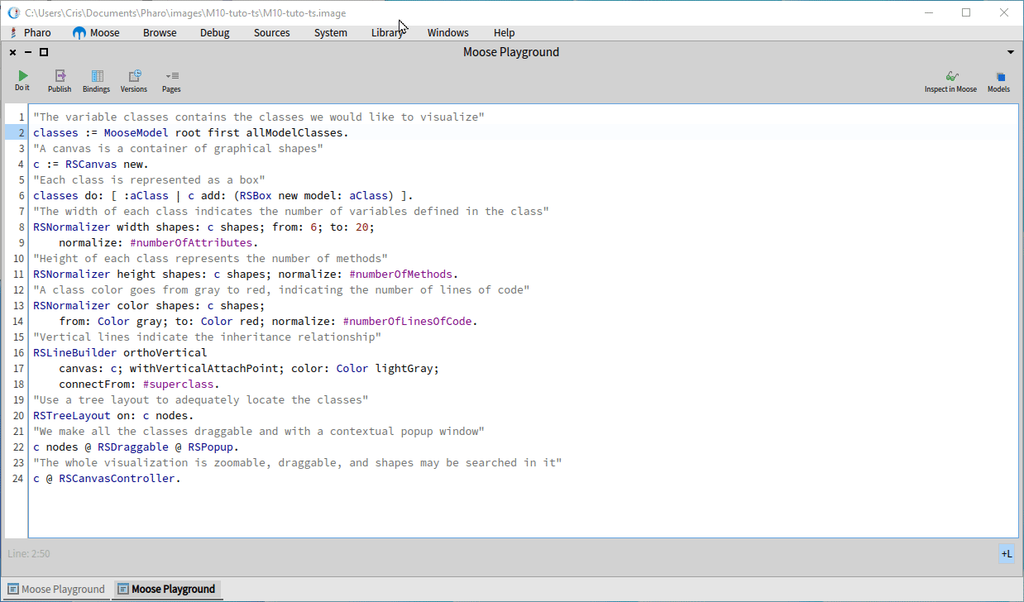

**Astuce**

La syntaxe avec le dièse utilisée à la ligne 9, **`normalize: #numberOfAttributes`**, est un raccourci syntaxique pour une expression de bloc plus longue : **`normalize: [:element | element numberOfAttributes ]`**. Parfois, vous voudrez effectuer un calcul sur la valeur utilisée dans la visualisation, par exemple en la combinant avec un autre attribut comme le nombre de **`receivingInvocations`**. Dans ce cas, vous feriez **`normalize: [:element | element numberOfAttributes + element receivingInvocations size ]`**.

La disposition (**`RSTreeLayout`**) permet également de visualiser la hiérarchie des classes en ce qui concerne l’héritage. Cependant, le projet **emojiopoly** n’utilise pas l’héritage en TypeScript, donc aucune arborescence n’est visible dans la visualisation.

# Conclusion

Vous avez effectué les étapes nécessaires pour analyser des programmes en TypeScript à l’aide de l’outil Moose dans Pharo, en utilisant un métamodèle Famix et un importateur (**`ts2famix`**).

Il est important de comprendre que le métamodèle influence également d’autres éléments du processus, notamment l’importateur et le fichier **`.json`** qu’il génère (le modèle).

L’importateur `ts2famix` dépend du métamodèle FamixTypeScript, car il transforme un programme TypeScript en modèle Famix, selon la structure du métamodèle.